# Analysis of Illinois Traffic Stops

Tyler W Edwards

- The Dataset that we will be looking at in this report is a record of traffic stops carried out by various law enforement agencies in the state of Illinois during the year 2017.
  - Let’s start by seeing what information the data can show us.

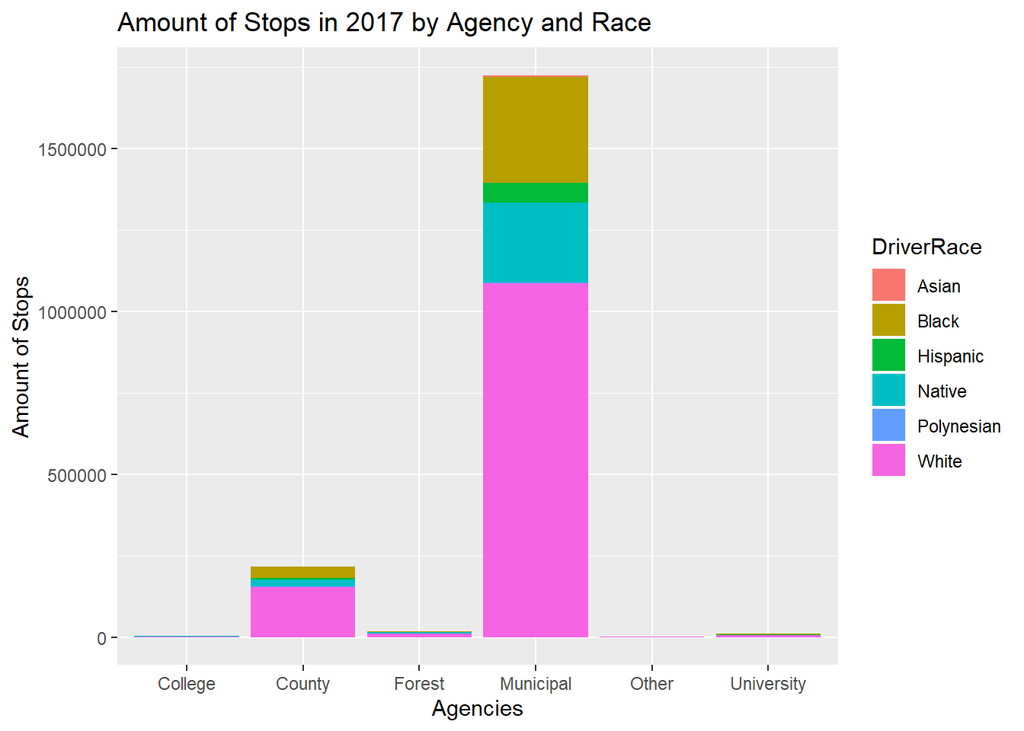

```r
ggplot(clean, aes(x=AgencyName, fill=DriverRace)) +
  geom_histogram(stat = "count") + labs(title = "Amount of Stops in 2017 by Agency and Race",
                                        x="Agencies", y="Amount of Stops")
```

- It looks like the Municipal agencies make the vast majority of stops by far. Let’s also see what the stops per day looks like.

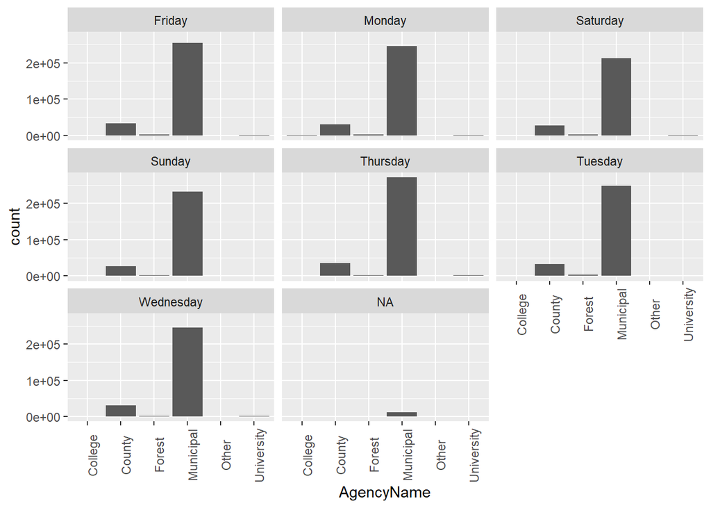

```r
ggplot(clean, aes(x=AgencyName)) +
  geom_histogram(stat="count") + facet_wrap(~StopWeekday)+
  theme(axis.text.x = element_text(angle = 90))
```

- It looks like we’ve got some good variation that we can look at with this data. Let’s also take a look at amount of stops conducted by Agency.

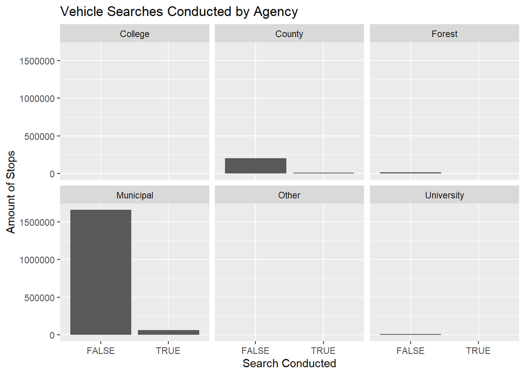

```r
ggplot(clean, aes(x=VehicleSearchConducted)) +
  geom_histogram(stat="count") + facet_wrap(~AgencyName) +
  labs(title = "Vehicle Searches Conducted by Agency", x="Search Conducted", y="Amount of Stops")
```

- So far it looks like the Municipal departments have the most data, and they’re followed by County, Forest, and University departments. Now, let’s start analyzing the data to see if we can find any trends in the data.
- Throughout this analysis, we will be trying to see if there are any trends that appear from the data. Mostly, we will be seeing if there are any trends based on Race, Location, Age, and a few other variables.

### Before we start analyzing, let’s take a look at the columns we’ll be using to analyze the data.

| Column ID | Description |
| --- | --- |
| **AgencyName** | The Categorized departments that processed the traffic stop. |
| **AgencyCode** | The code assigned to each Police Department. |
| **DriversYearofBirth** | Pretty self explanatory |
| **DriverSex** | Also pretty self explanatory |
| **DriverRace** | The races of the people who were stopped. (White, Black, Asian, Native, Polynesian, and Hispanic ) |
| **VehicleSearchConducted** | Whether a vehicle search was conducted or not. |
| **VehicleContrabandFound** | Whether contraband was found in the vehicle or not |
| **VehicleDrugsFound** | Whether Drugs were found in the vehicle or not |

- It is also important to note that the Agency Names have been changed to fit into categories; these categories are Municipal, University, College, Forest, County, and Other.

### Now that we sort of know what is in this data set, lets start some analysis.

- The first thing that I want to know is what effect Driver Race has on the probability of a search being conducted. That being said, let’s see what a plot would look like that is based on the following model.

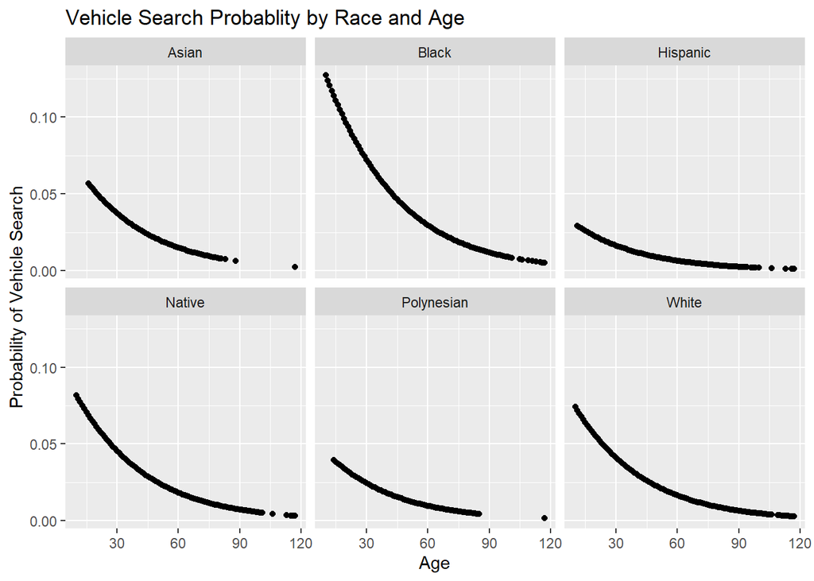

```r
mod1 <- glm(data=clean, VehicleSearchConducted ~ DriverRace + Age, family="binomial")
clean <- add_predictions(clean,mod1,type="response",var="ProbOfSearchmod1")

plot1 <- ggplot(clean, aes(x=Age, y=ProbOfSearchmod1)) +
  geom_point() + facet_wrap(~DriverRace)+
  labs(title = "Vehicle Search Probablity by Race and Age", y="Probability of Vehicle Search")

plot1
```

- So far it seems that certain Driver Races has a significant effect on the Probability of a search being conducted. Also, Age is a significant predictor of probability. However, we still need to take a look at the model to see if our assumptions are actually correct.

```r
summary(mod1)
```

```
##
## Call:
## glm(formula = VehicleSearchConducted ~ DriverRace + Age, family = "binomial",
##     data = clean)
##
## Deviance Residuals:
##     Min       1Q   Median       3Q      Max
## -0.5219  -0.3293  -0.2772  -0.2141   3.4290
##
## Coefficients:
##                        Estimate Std. Error  z value Pr(>|z|)
## (Intercept)          -2.3098444  0.0704611  -32.782  < 2e-16 ***
## DriverRaceBlack       0.6981614  0.0701629    9.951  < 2e-16 ***
## DriverRaceHispanic   -0.8480636  0.0775566  -10.935  < 2e-16 ***
## DriverRaceNative      0.2053619  0.0704881    2.913  0.00357 **
## DriverRacePolynesian -0.4393828  0.1342044   -3.274  0.00106 **
## DriverRaceWhite       0.0972505  0.0700189    1.389  0.16486
## Age                  -0.0313132  0.0002947 -106.262  < 2e-16 ***
## ---
## Signif. codes:  0 '***' 0.001 '**' 0.01 '*' 0.05 '.' 0.1 ' ' 1
##
## (Dispersion parameter for binomial family taken to be 1)
##
##     Null deviance: 681946  on 1973275  degrees of freedom
## Residual deviance: 660545  on 1973269  degrees of freedom
## AIC: 660559
##
## Number of Fisher Scoring iterations: 6
```

- Just by looking at the P-values for each race, it seems that every race except for White is a significant deciding factor in whether a search is conducted. Age is also a significant factor.

*Now I want to know if there are any differences in the trends based on the added effects of the varying Agencies. Let’s take a look.

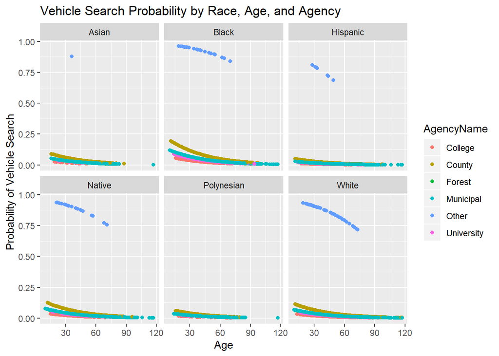

```r
mod2 <- glm(data=clean, VehicleSearchConducted ~ DriverRace + Age + AgencyName, family="binomial")
clean <- add_predictions(clean, mod2, type="response",var="ProbOfSearchmod2")

plot2 <- ggplot(clean, aes(x=Age, y=ProbOfSearchmod2, color=AgencyName)) +
  geom_point() + facet_wrap(~DriverRace)+
  labs(title = "Vehicle Search Probability by Race, Age, and Agency", y="Probability of Vehicle Search")

plot2
```

- Now it seems that the Agencies have a significant effect on the probabilities! Let’s check the model again.

```r
summary(mod2)
```

```
##
## Call:
## glm(formula = VehicleSearchConducted ~ DriverRace + Age + AgencyName,
##     family = "binomial", data = clean)
##
## Deviance Residuals:
##     Min       1Q   Median       3Q      Max
## -2.5648  -0.3237  -0.2724  -0.2093   3.4586
##
## Coefficients:
##                        Estimate Std. Error  z value Pr(>|z|)
## (Intercept)          -3.0596259  0.1306337  -23.421  < 2e-16 ***
## DriverRaceBlack       0.7288636  0.0703603   10.359  < 2e-16 ***
## DriverRaceHispanic   -0.7975939  0.0777759  -10.255  < 2e-16 ***
## DriverRaceNative      0.2401116  0.0706860    3.397 0.000682 ***
## DriverRacePolynesian -0.4344895  0.1343732   -3.233 0.001223 **
## DriverRaceWhite       0.1031556  0.0702136    1.469 0.141787
## Age                  -0.0314280  0.0002957 -106.287  < 2e-16 ***
## AgencyNameCounty      1.2484750  0.1104437   11.304  < 2e-16 ***
## AgencyNameForest      0.5859546  0.1169642    5.010 5.45e-07 ***
## AgencyNameMunicipal   0.6552788  0.1101681    5.948 2.71e-09 ***
## AgencyNameOther       6.1790847  0.2732274   22.615  < 2e-16 ***
## AgencyNameUniversity  0.4323896  0.1205723    3.586 0.000336 ***
## ---
## Signif. codes:  0 '***' 0.001 '**' 0.01 '*' 0.05 '.' 0.1 ' ' 1
##
## (Dispersion parameter for binomial family taken to be 1)
##
##     Null deviance: 681946  on 1973275  degrees of freedom
## Residual deviance: 656230  on 1973264  degrees of freedom
## AIC: 656254
##
## Number of Fisher Scoring iterations: 6
```

- Again, Almost all races are deciding factors. However, this time, the graph shows some different info with the Agencies showing some new connections. It seems that the “Other” Agencies have the highest probability of searching vehicles belonging to peole of the Black, Native, Hispanic, and White Races.
  - Although we are seeing this trend, we don’t have the information on population densities that could possibly explain these trends further.

### Next, lets try to find some trends in Contraband found and Drugs found during searches.

- Like the last round of models, let’s first look at how Driver Race and Age affect the probability of Contraband being found during a vehicle search. We’ll look at a plot first.

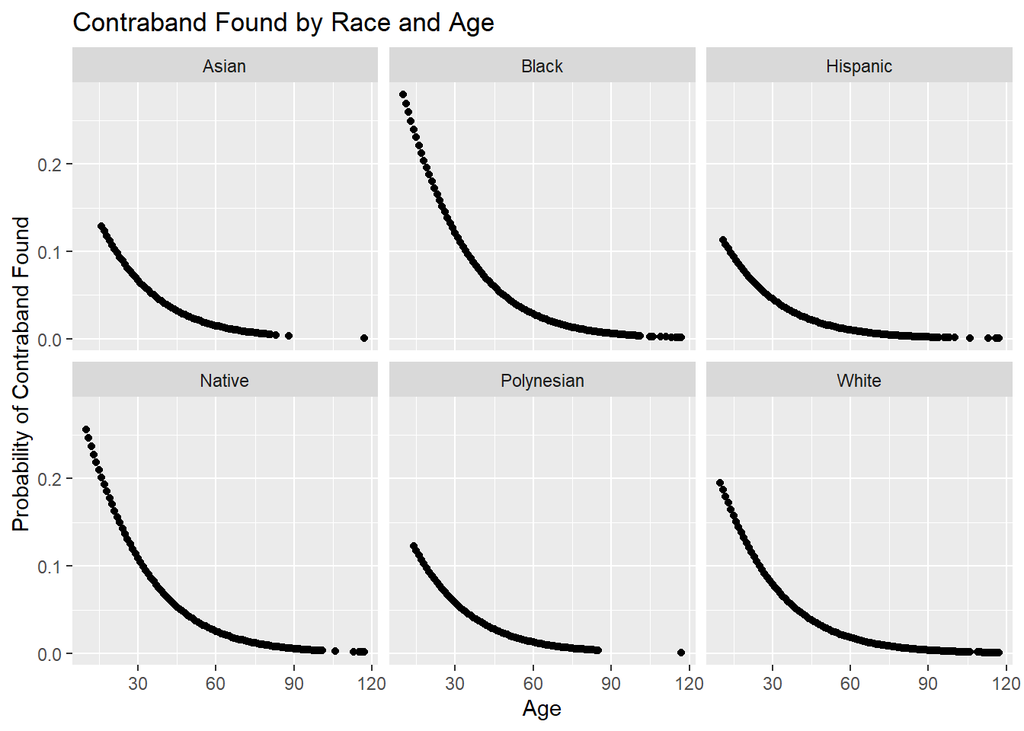

```r
mod3 <- glm(data=clean, VehicleContrabandFound ~ DriverRace + Age,family="binomial")
clean <- add_predictions(data=clean,mod3, type="response", var="ProbOfContramod3")

plot3 <- ggplot(clean, aes(x=Age, y=ProbOfContramod3))+
  geom_point() + facet_wrap(~DriverRace) +
  labs(title = "Contraband Found by Race and Age", y = "Probability of Contraband Found")

plot3
```

*As expected, the Age and Race seem be significant factors. Let’s check the model.

```r
summary(mod3)
```

```
##
## Call:
## glm(formula = VehicleContrabandFound ~ DriverRace + Age, family = "binomial",
##     data = clean)
##
## Deviance Residuals:
##     Min       1Q   Median       3Q      Max
## -0.8091  -0.4952  -0.3872  -0.2561   3.7264
##
## Coefficients:
##                        Estimate Std. Error z value Pr(>|z|)
## (Intercept)          -1.0850912  0.1415934  -7.663 1.81e-14 ***
## DriverRaceBlack       0.6528786  0.1407488   4.639 3.51e-06 ***
## DriverRaceHispanic   -0.4051857  0.1531941  -2.645 0.008171 **
## DriverRaceNative      0.5338262  0.1413092   3.778 0.000158 ***
## DriverRacePolynesian -0.1549258  0.2572710  -0.602 0.547048
## DriverRaceWhite       0.1844116  0.1405638   1.312 0.189540
## Age                  -0.0516359  0.0006599 -78.248  < 2e-16 ***
## ---
## Signif. codes:  0 '***' 0.001 '**' 0.01 '*' 0.05 '.' 0.1 ' ' 1
##
## (Dispersion parameter for binomial family taken to be 1)
##
##     Null deviance: 176517  on 300872  degrees of freedom
## Residual deviance: 166816  on 300866  degrees of freedom
##   (1672403 observations deleted due to missingness)
## AIC: 166830
##
## Number of Fisher Scoring iterations: 6
```

*This time, there are fewer races that seem to be significant factors.

*Next, let’s factor in the Agencies again to see what results we see.

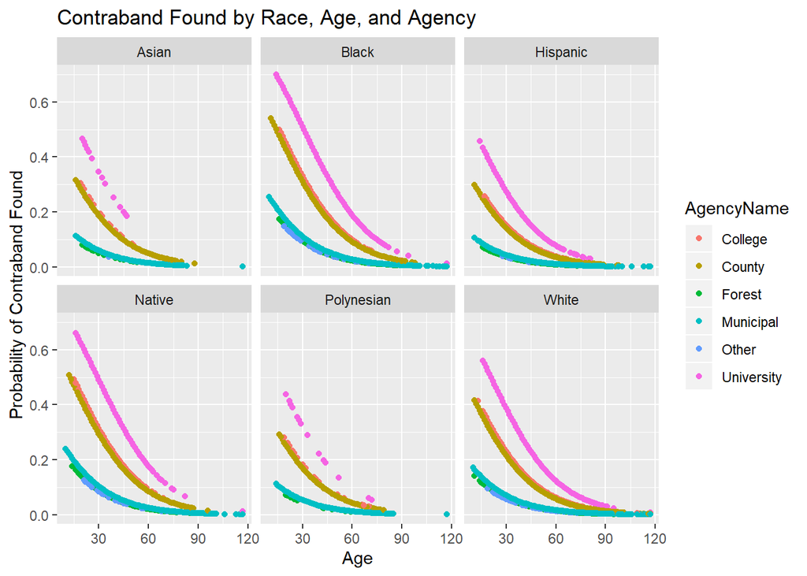

```r
mod4 <- glm(data = clean, VehicleContrabandFound ~ DriverRace + Age + AgencyName, family="binomial")
clean <- add_predictions(data = clean,mod4,type="response", var="ProbOfContramod4")

plot4 <- ggplot(clean, aes(x=Age, y=ProbOfContramod4, color=AgencyName))+
  geom_point() + facet_wrap(~DriverRace) +
  labs(title = "Contraband Found by Race, Age, and Agency", y = "Probability of Contraband Found")

plot4
```

- There are a couple of remarkable trends going on this time. It seems that there is a significant increase in probability of contraband found during searches conducted by University, County, and College. Let’s check the model.

```r
summary(mod4)
```

```
##
## Call:
## glm(formula = VehicleContrabandFound ~ DriverRace + Age + AgencyName,
##     family = "binomial", data = clean)
##
## Deviance Residuals:
##     Min       1Q   Median       3Q      Max
## -1.5509  -0.4741  -0.3730  -0.2460   3.7267
##
## Coefficients:
##                        Estimate Std. Error z value Pr(>|z|)
## (Intercept)           0.1248378  0.2763823   0.452 0.651496
## DriverRaceBlack       0.6771910  0.1417770   4.776 1.78e-06 ***
## DriverRaceHispanic   -0.3354760  0.1542310  -2.175 0.029619 *
## DriverRaceNative      0.6003534  0.1423400   4.218 2.47e-05 ***
## DriverRacePolynesian -0.1140197  0.2586670  -0.441 0.659360
## DriverRaceWhite       0.1782823  0.1415814   1.259 0.207950
## Age                  -0.0501449  0.0006626 -75.684  < 2e-16 ***
## AgencyNameCounty     -0.0921811  0.2377326  -0.388 0.698200
## AgencyNameForest     -1.5606599  0.2455591  -6.356 2.08e-10 ***
## AgencyNameMunicipal  -1.3793000  0.2369880  -5.820 5.88e-09 ***
## AgencyNameOther      -1.6098532  0.4581940  -3.513 0.000442 ***
## AgencyNameUniversity  0.7454432  0.2549563   2.924 0.003458 **
## ---
## Signif. codes:  0 '***' 0.001 '**' 0.01 '*' 0.05 '.' 0.1 ' ' 1
##
## (Dispersion parameter for binomial family taken to be 1)
##
##     Null deviance: 176517  on 300872  degrees of freedom
## Residual deviance: 163289  on 300861  degrees of freedom
##   (1672403 observations deleted due to missingness)
## AIC: 163313
##
## Number of Fisher Scoring iterations: 6
```

### Lastly, I want to see if there are any trends in drugs being found.

- Let’s just cut straight to the chase and run a model to determine the probability of drugs being found as influenced by Race, Age, and Agency.

```r
mod5 <- glm(data = clean, VehicleDrugsFound ~ (DriverRace * AgencyName) + Age, family = "binomial")
clean <- add_predictions(data = clean,mod5,type="response", var="ProbOfDrugsmod5")
```

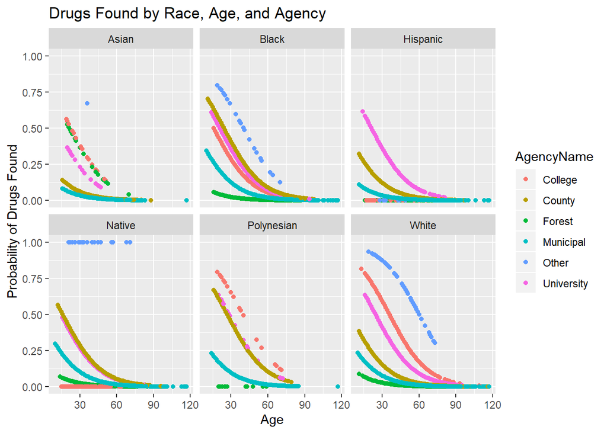

```r
plot5 <- ggplot(clean, aes(x=Age, y=ProbOfDrugsmod5, color=AgencyName)) +
  geom_point() + facet_wrap(~DriverRace) +
  labs(title = "Drugs Found by Race, Age, and Agency", y = "Probability of Drugs Found")

plot5
```

- It seems that there is a strong correlation between a few races, and the “Other” Agencies. Let’s see what we can find in the model.

```r
summary(mod5)
```

```
##
## Call:
## glm(formula = VehicleDrugsFound ~ (DriverRace * AgencyName) +
##     Age, family = "binomial", data = clean)
##
## Deviance Residuals:
##     Min       1Q   Median       3Q      Max
## -1.7287  -0.5017  -0.3440  -0.2008   4.0282
##
## Coefficients: (8 not defined because of singularities)
##                                             Estimate Std. Error z value
## (Intercept)                                1.481e+00  5.134e-01   2.885
## DriverRaceBlack                           -4.467e-01  6.621e-01  -0.675
## DriverRaceHispanic                        -1.182e+01  1.970e+02  -0.060
## DriverRaceNative                          -1.148e+01  1.388e+02  -0.083
## DriverRacePolynesian                       1.096e+00  3.277e-01   3.346
## DriverRaceWhite                            8.466e-01  1.904e-01   4.447
## AgencyNameCounty                          -2.257e+00  7.302e-01  -3.091
## AgencyNameForest                          -8.790e-02  1.505e+00  -0.058
## AgencyNameMunicipal                       -2.857e+00  4.764e-01  -5.998
## AgencyNameOther                            1.569e+00  1.203e+00   1.305
## AgencyNameUniversity                      -7.319e-01  5.102e-01  -1.435
## Age                                       -6.482e-02  8.496e-04 -76.290
## DriverRaceBlack:AgencyNameCounty           2.800e+00  8.432e-01   3.320
## DriverRaceHispanic:AgencyNameCounty        1.257e+01  1.970e+02   0.064
## DriverRaceNative:AgencyNameCounty          1.330e+01  1.388e+02   0.096
## DriverRacePolynesian:AgencyNameCounty      1.430e+00  1.545e+00   0.925
## DriverRaceWhite:AgencyNameCounty           1.712e-01  5.542e-01   0.309
## DriverRaceBlack:AgencyNameForest          -2.720e+00  1.572e+00  -1.731
## DriverRaceHispanic:AgencyNameForest        8.855e-01  2.008e+02   0.004
## DriverRaceNative:AgencyNameForest          8.395e+00  1.388e+02   0.060
## DriverRacePolynesian:AgencyNameForest     -1.127e+01  1.970e+02  -0.057
## DriverRaceWhite:AgencyNameForest          -3.846e+00  1.431e+00  -2.687
## DriverRaceBlack:AgencyNameMunicipal        1.823e+00  6.344e-01   2.874
## DriverRaceHispanic:AgencyNameMunicipal     1.180e+01  1.970e+02   0.060
## DriverRaceNative:AgencyNameMunicipal       1.265e+01  1.388e+02   0.091
## DriverRacePolynesian:AgencyNameMunicipal          NA         NA      NA
## DriverRaceWhite:AgencyNameMunicipal               NA         NA      NA
## DriverRaceBlack:AgencyNameOther                   NA         NA      NA
## DriverRaceHispanic:AgencyNameOther                NA         NA      NA
```

[output cut: 42 more lines]

```
## DriverRaceHispanic:AgencyNameUniversity   0.949619
## DriverRaceNative:AgencyNameUniversity     0.932932
## DriverRacePolynesian:AgencyNameUniversity       NA
## DriverRaceWhite:AgencyNameUniversity            NA
## ---
## Signif. codes:  0 '***' 0.001 '**' 0.01 '*' 0.05 '.' 0.1 ' ' 1
##
## (Dispersion parameter for binomial family taken to be 1)
##
##     Null deviance: 119585  on 197765  degrees of freedom
## Residual deviance: 107284  on 197737  degrees of freedom
##   (1775510 observations deleted due to missingness)
## AIC: 107342
##
## Number of Fisher Scoring iterations: 10
```

## Discussion

*Lastly, there is a pretty big problem with the majority of these models. Even if we find significance in the deciding factors for each model, because they all depend on the driver’s race, we need to know the population density of each race in order to really see if the significance would still hold up; we’ll need more data for future analyses.